# Social Media

Shubham Bhargava 2024-03-27

```r
library(readxl)
library(dplyr)
library(FactoMineR)
library(factoextra)
```

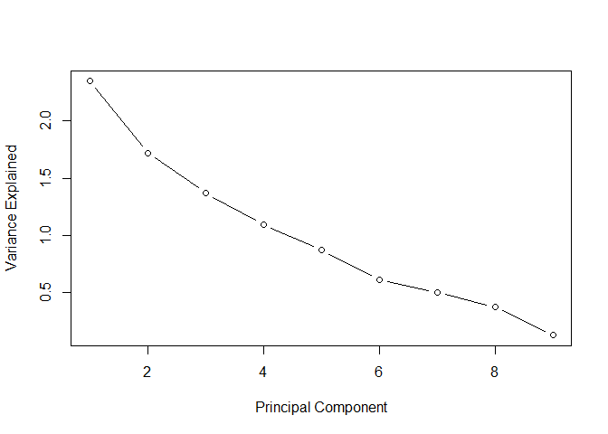

```r
social_media <- read_excel("social_media_cleaned.xlsx")

social_media_numeric <- select_if(social_media, is.numeric)

# Perform PCA
pca_result <- prcomp(social_media_numeric, scale = TRUE)

# Scree plot
plot(pca_result$sdev^2, type = "b", xlab = "Principal Component", ylab = "Variance Explained")
```

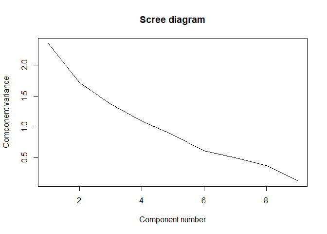

```r
#From PCA variate representation of each PC, It’s evident that PC1 and PC2 add arround 50% of the to total variance

plot(pca_result$sdev^2, xlab = "Component number", ylab = "Component variance", type = "l", main = "Scree diagram")
```

```r
# Loadings
loadings <- pca_result$rotation
print(loadings)
```

```
##                                       PC1          PC2         PC3        PC4
## Instagram                      0.35997253 -0.235305731 -0.48074695  0.1123396
## LinkedIn                       0.39149535 -0.188256641  0.42154260 -0.2431677
## SnapChat                       0.14434470 -0.001375426 -0.53148137 -0.5851768
## Twitter                       -0.38928919 -0.485292758  0.14824132 -0.2290724
## Whatsapp/Wechat                0.49712209  0.001226222 -0.14994837  0.2121451
## youtube                        0.43321201 -0.232497668  0.25452061  0.3341619
## OTT                            0.02991209 -0.694285079 -0.10777759 -0.1630966
## Reddit                        -0.14824451 -0.346301530  0.09853811  0.2831951
## How you felt the entire week?  0.29511949  0.132915416  0.42207257 -0.5194936
##                                       PC5         PC6        PC7         PC8
## Instagram                      0.13976700 -0.31408369  0.4516641 -0.49586684
## LinkedIn                      -0.11932387 -0.28841101 -0.5352279 -0.41219103
## SnapChat                      -0.34293942 -0.16571370 -0.1349190  0.39502630
## Twitter                        0.31769932  0.03070392  0.1596447  0.04109432
## Whatsapp/Wechat                0.03955265  0.70875864 -0.1526895  0.02249668
## youtube                        0.10599868 -0.36788501  0.1356451  0.64454084
## OTT                            0.13238183  0.29590419 -0.1450540  0.06870679
## Reddit                        -0.84276046  0.07699596  0.1923146 -0.07462750
## How you felt the entire week? -0.08435896  0.24207624  0.6050635 -0.01585044
##                                       PC9
## Instagram                     -0.05696856
## LinkedIn                      -0.14378008
## SnapChat                      -0.18692529
## Twitter                       -0.63987847
## Whatsapp/Wechat               -0.39705749
## youtube                       -0.03767887
## OTT                            0.58992497
## Reddit                        -0.09727197
## How you felt the entire week?  0.12308003
```

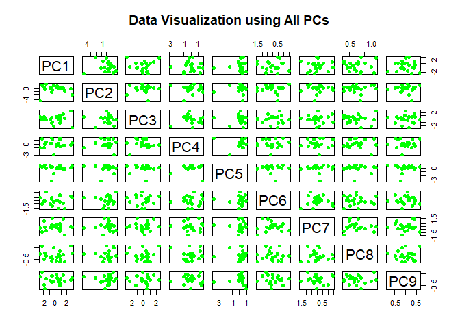

```r
# Data projection onto all PCs
data_projection_all <- as.data.frame(pca_result$x)

# Matrix scatterplot for pairs of principal components
pairs(data_projection_all, col = "green", pch = 19,
      main = "Data Visualization using All PCs")
```

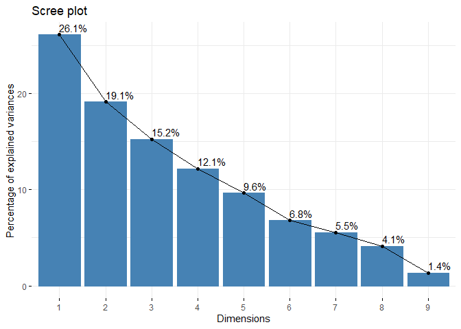

```r
# Visualize Eigenvalues
fviz_eig(pca_result, addlabels = TRUE)
```

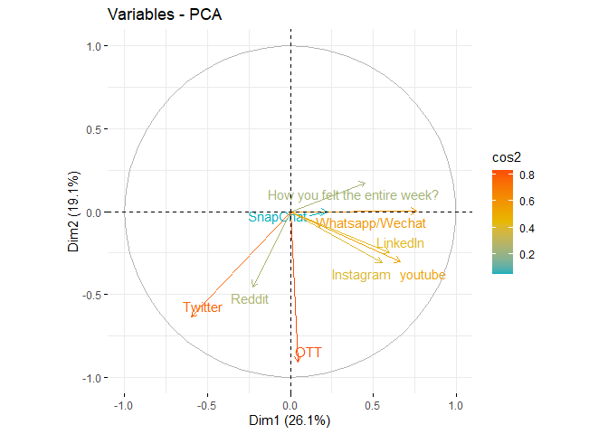

```r
# Visualize Variable Quality
fviz_pca_var(pca_result, col.var = "cos2",
             gradient.cols = c("#00AFBB", "#E7B800", "#FC4E07"),
             repel = TRUE)
```

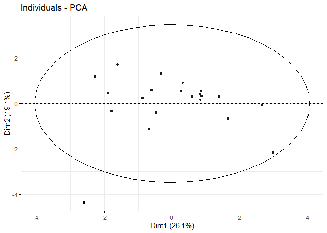

```r
# Visualize Individual Contributions
fviz_pca_ind(pca_result,
             geom.ind = "point", # Show points only
             palette = c("#00AFBB", "#E7B800", "#FC4E07"),
             addEllipses = TRUE, # Concentration ellipses
             legend.title = "Groups"
             )
```

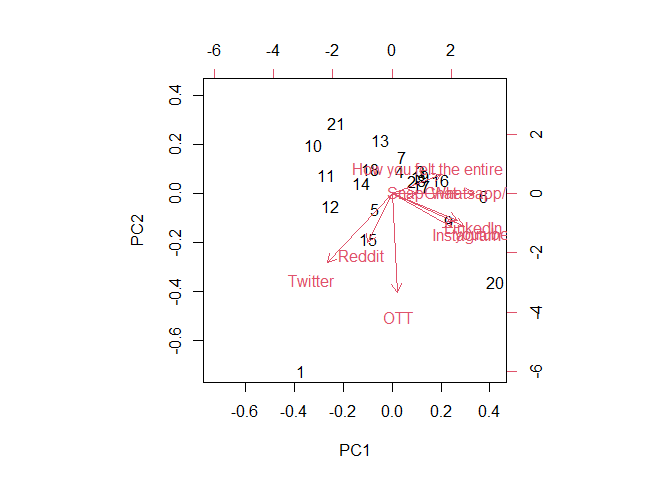

```r
# Biplot
biplot(pca_result)
```

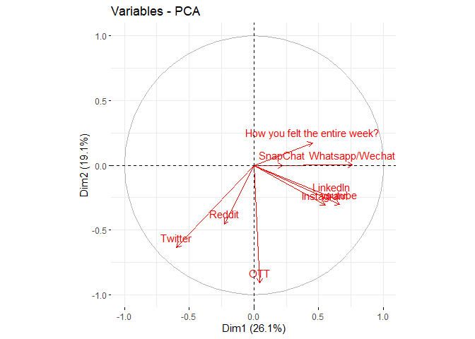

```r
# Variable correlation plot (Correlation Circle)
fviz_pca_var(pca_result, col.var = "red")
```

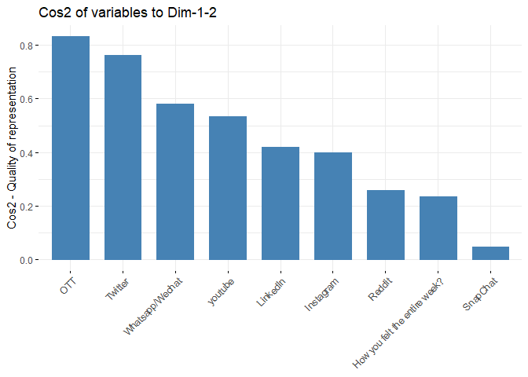

```r
# Quality of representation of variables on dimensions 1 and 2
fviz_cos2(pca_result, choice = "var", axes = 1:2)
```

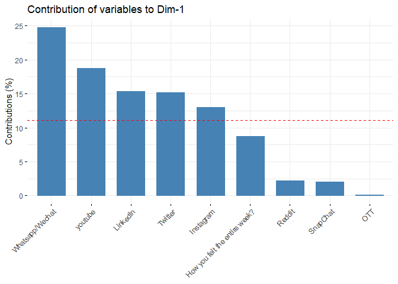

```r
# Contributions of variables to principal components
fviz_contrib(pca_result, choice = "var", axes = 1, top = 10)
```

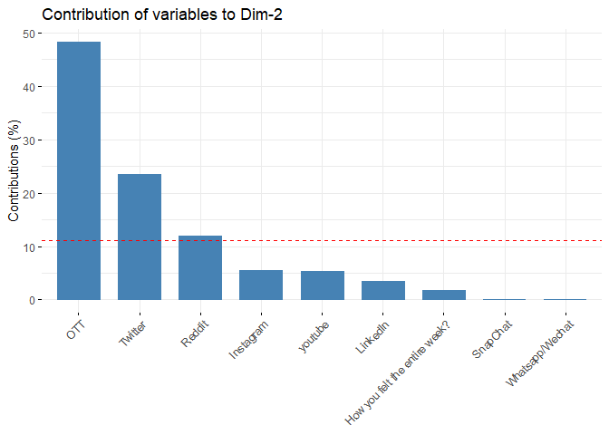

```r
fviz_contrib(pca_result, choice = "var", axes = 2, top = 10)
```

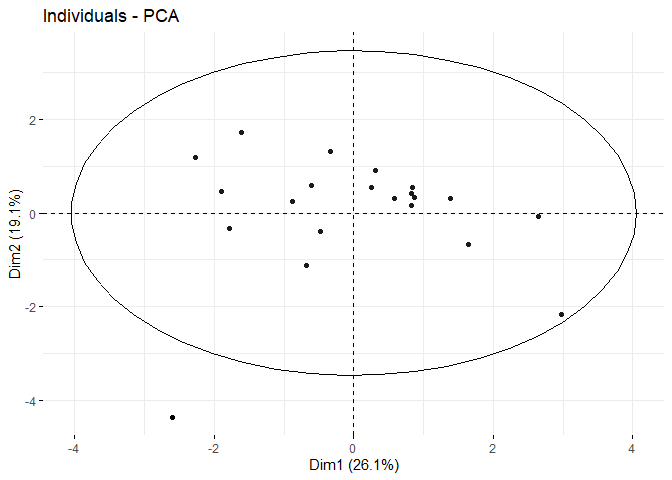

```r
# Visualize individual contributions
fviz_pca_ind(pca_result,
             geom.ind = "point", # Show points only
             palette = c("#00AFBB", "#E7B800", "#FC4E07"),
             addEllipses = TRUE, # Concentration ellipses
             legend.title = "Groups"
             )
```

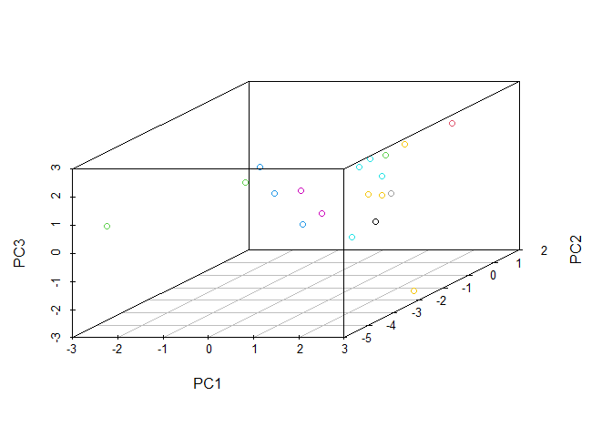

```r
library(scatterplot3d)
scatterplot3d(pca_result$x[,1:3], color = social_media$Instagram)
```

### Cluster Analysis

```r
library(readxl)
library(factoextra)
library(ggplot2)
library(factoextra)
library(ggfortify)
library(MASS)
library(ggrepel)
library(stats)


social_media_cluster <- read_excel("social_media_cleaned.xlsx")
data.scaled <- scale(x = social_media_cluster[, -1], center = TRUE, scale = TRUE)
data <- data.scaled
head(data)
```

```
##       Instagram   LinkedIn   SnapChat     Twitter Whatsapp/Wechat    youtube
## [1,] -0.6888867  0.1519097 -0.2810325  3.42451853      -1.3480276 -0.2719612
## [2,]  0.5146906  0.6366870  0.4933528 -0.44951033      -0.5576781  0.7352180
## [3,] -0.6130708  1.3638528 -0.4157082 -0.44951033       0.8450887 -0.6460563
## [4,] -0.1534369  0.6838181 -0.1944552 -0.44951033      -0.2804351 -0.5597267
## [5,]  1.7277449 -1.2283589 -0.5696232  0.06702685      -0.8514729  0.3035697
## [6,] -1.0205812  1.3638528 -0.4349475 -0.44951033       1.3830228  2.3179281
##             OTT     Reddit How you felt the entire week?
## [1,]  3.4382238  1.2405563                    -0.5741693
## [2,] -0.6686547 -0.3292004                    -0.5741693
## [3,] -0.1021887 -0.3292004                     0.7655590
## [4,] -0.1021887 -0.3292004                     0.7655590
## [5,] -0.1021887  0.2987023                    -0.5741693
## [6,]  0.1810443 -0.3292004                     2.1052873
```

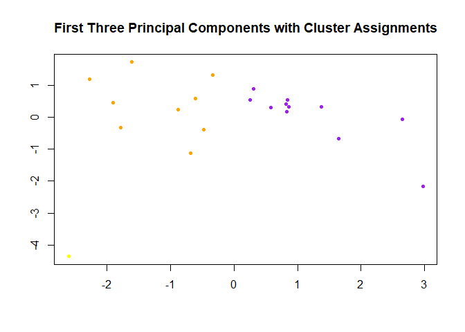

```r
# Perform PCA
pc <- prcomp(data.scaled)
pc_first_three <- pc$x[, 1:3]
# Perform K-means clustering on the first three principal components
set.seed(123)  # For reproducibility
k <- 3  # Number of clusters
km_clusters <- kmeans(pc_first_three, centers = k)

# Define colors for each cluster
cluster_colors <- c("yellow", "purple", "orange")

# Plot the first three principal components with cluster assignments
plot(pc_first_three, col = cluster_colors[km_clusters$cluster],
     main = "First Three Principal Components with Cluster Assignments",
     xlab = "", ylab = "", pch = 20)
```

It is first performs Principal Component Analysis (PCA) on scaled data, reducing its dimensionality.

Then, it extracts the first three principal components. Next, it applies K-means clustering to these components, dividing data into three clusters.

Finally, it plots the first three principal components with color-coded cluster assignments for visualization and analysis

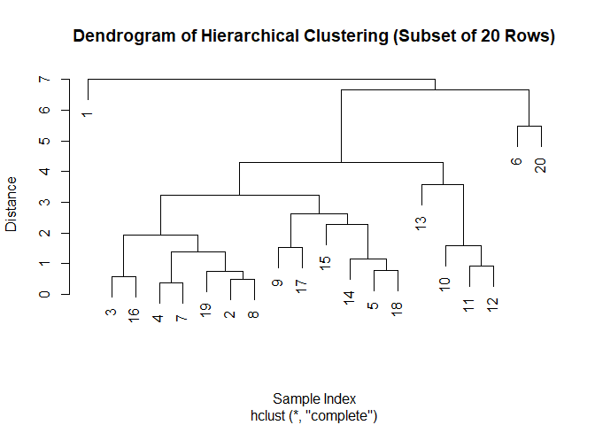

```r
# Take a subset of 20 rows
data_subset <- data[1:20, ]

# Perform PCA
pca_result <- prcomp(data_subset)

# Extract the first three principal components
pc_first_three <- pca_result$x[, 1:3]

# Perform hierarchical clustering on the first three principal components
hc <- hclust(dist(pc_first_three))

# Plot the dendrogram
plot(hc, main = "Dendrogram of Hierarchical Clustering (Subset of 20 Rows)",
     xlab = "Sample Index", ylab = "Distance", sub = NULL)
```

The plot shows the first three principal components, performs hierarchical clustering on them, and plots a dendrogram showing the relationships between the samples based on their distances in the reduced-dimensional space.

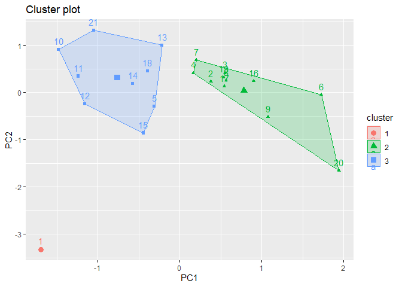

```r
# Visualize cluster and membership using first two Principal Components
fviz_cluster(list(data = pc$x[, 1:2], cluster = km_clusters$cluster))
```

This plot visualizes clustering results by plotting data points in a two-dimensional space using the first two Principal Components. Each point is colored according to its assigned cluster, showing the grouping pattern identified by the clustering algorithm. It helps understand how data points are grouped based on their features.

```r
# Non-hierarchical clustering (k-means)
num_clusters <- 2
kmeans_model <- kmeans(data, centers = num_clusters)

# Membership for each cluster
table(kmeans_model$cluster)
```

```
##
##  1  2
## 11 10
```

This represents clustering using the k-means algorithm, dividing data into two clusters. It initializes cluster centers randomly, assigning each data point to the nearest cluster. The table function counts the number of data points assigned to each cluster, providing insight into cluster membership and distribution.

This represents clustering using the k-means algorithm, dividing data into two clusters. It initializes cluster centers randomly, assigning each data point to the nearest cluster. The table function counts the number of data points assigned to each cluster, providing insight into cluster membership and distribution.

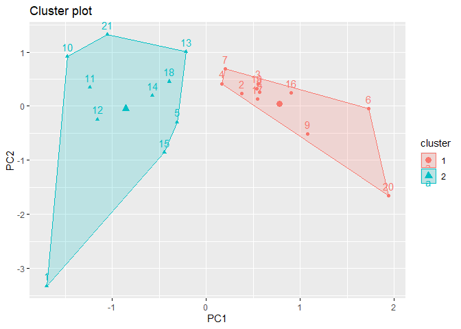

```r
# Visualize cluster and membership using first two Principal Components
fviz_cluster(list(data = pc$x[, 1:2], cluster = kmeans_model$cluster))
```

This plot visualizes clusters and their memberships using the first two principal components. It extracts these components from the data, then assigns each data point to a cluster using k-means clustering. Finally, it creates a visual representation showing how the data points are grouped based on their similarities in the first two principal components.

What is the relationship between the clustering results obtained through k-means algorithm and the underlying structure of the data as revealed by Principal Component Analysis (PCA)?

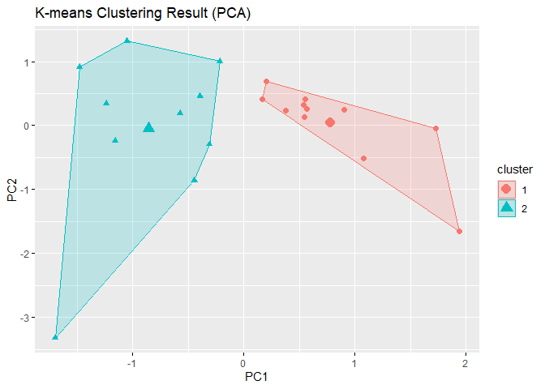

```r
# Visualize cluster and membership using first two Principal Components for k-means
pca_result <- prcomp(data, scale = TRUE)
fviz_cluster(kmeans_model, data = pca_result$x[, 1:2], geom = "point",
             pointsize = 2, fill = "white", main = "K-means Clustering Result (PCA)")
```

What is the relationship between the number of clusters (k) and the average silhouette width in k-means clustering, and how does this relationship inform the determination of the optimal number of clusters for a given dataset?

```
##   cluster size ave.sil.width
## 1       1   11          0.26
## 2       2   10          0.04
```

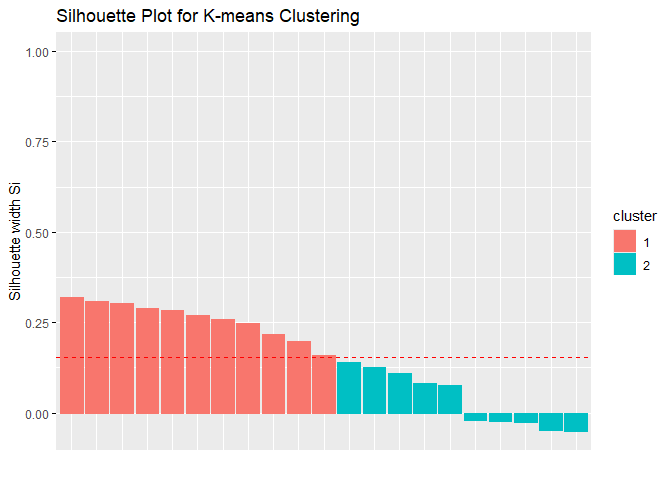

```r
library(factoextra)
library(cluster)

# Calculate silhouette information for k-means clustering
sil <- silhouette(kmeans_model$cluster, dist(data))

# Visualize the silhouette plot for k-means clustering
fviz_silhouette(sil, main = "Silhouette Plot for K-means Clustering")
```

This plot calculates and visualizes the silhouette information for k-means clustering. Silhouette analysis helps evaluate the quality of clustering by measuring how similar an object is to its own cluster compared to other clusters. A higher silhouette width indicates better separation of clusters, while negative values suggest that points might be assigned to the wrong clusters. This plot helps in determining the optimal number of clusters for k-means clustering and assessing the overall clustering performance.

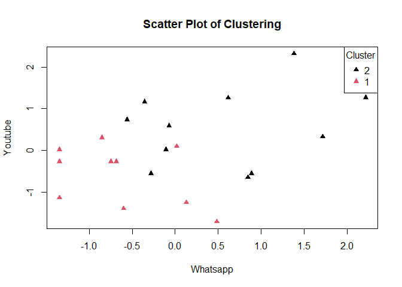

```r
# Create a data frame with cluster membership
data_clustered <- data.frame(data, Cluster = kmeans_model$cluster)  # Ensure conversion to data frame

# Scatter plot of data points colored by cluster membership
plot(data_clustered$Whatsapp.Wechat, data_clustered$youtube,
     col = data_clustered$Cluster, pch = 17,
     xlab = "Whatsapp", ylab = "Youtube",
     main = "Scatter Plot of Clustering")
legend("topright", legend = unique(data_clustered$Cluster),
       col = 1:max(data_clustered$Cluster), pch = 17, title = "Cluster")
```

Overall, this plot visualizes clusters in the data, helping us understand how data points group together based on the Whatsapp and Youtube, with each group represented by a different color on the plot.

### Factor Analysis

[output not shown]

[output cut: 22 more lines]

[output not shown]

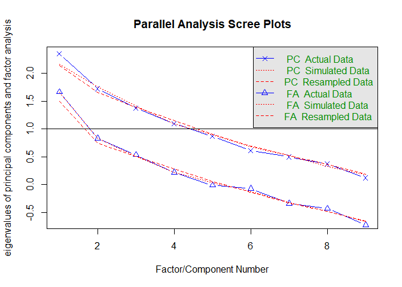

```
## Parallel analysis suggests that the number of factors =  0  and the number of components =  0
```

```r
library(ggplot2)
library(psych)
fa.parallel(social_media_numeric)
```

Parallel analysis suggests that the number of factors = 0 and the number of components = 0

```r
fit.pc <- principal(social_media_numeric, nfactors=2, rotate="varimax")
fit.pc
```

```
## Principal Components Analysis
## Call: principal(r = social_media_numeric, nfactors = 2, rotate = "varimax")
## Standardized loadings (pattern matrix) based upon correlation matrix
##                                 RC1   RC2    h2   u2 com
## Instagram                      0.63  0.09 0.400 0.60 1.0
## LinkedIn                       0.65  0.01 0.421 0.58 1.0
## SnapChat                       0.21 -0.08 0.049 0.95 1.3
## Twitter                       -0.32  0.81 0.761 0.24 1.3
## Whatsapp/Wechat                0.71 -0.28 0.581 0.42 1.3
## youtube                        0.73  0.04 0.534 0.47 1.0
## OTT                            0.37  0.83 0.832 0.17 1.4
## Reddit                        -0.05  0.51 0.258 0.74 1.0
## How you felt the entire week?  0.36 -0.33 0.235 0.77 2.0
##
##                        RC1  RC2
## SS loadings           2.27 1.80
## Proportion Var        0.25 0.20
## Cumulative Var        0.25 0.45
## Proportion Explained  0.56 0.44
## Cumulative Proportion 0.56 1.00
##
## Mean item complexity =  1.3
## Test of the hypothesis that 2 components are sufficient.
##
## The root mean square of the residuals (RMSR) is  0.14
##  with the empirical chi square  29.01  with prob <  0.066
##
## Fit based upon off diagonal values = 0.66
```

High absolute values (close to 1) indicate a strong relationship between the variable and the factor. \#h2 explains how much variance of the variables are explained by the factors. \#u2 indicates the amount of variance not explained by the factors Principal Components Analysis Call: principal(r = social_media_numeric, nfactors = 2, rotate = “varimax”) Standardized loadings (pattern matrix) based upon correlation matrix

SS loadings 2.27 1.80 Proportion Var 0.25 0.20 Cumulative Var 0.25 0.45 Proportion Explained 0.56 0.44 Cumulative Proportion 0.56 1.00

Mean item complexity = 1.3 Test of the hypothesis that 2 components are sufficient.

The root mean square of the residuals (RMSR) is 0.14 with the empirical chi square 29.01 with prob < 0.066

```r
round(fit.pc$values, 3)
```

```
## [1] 2.349 1.721 1.370 1.093 0.867 0.611 0.497 0.369 0.122
```

```r
fit.pc$loadings
```

```
##
## Loadings:
##                               RC1    RC2
## Instagram                      0.626
## LinkedIn                       0.649
## SnapChat                       0.207
## Twitter                       -0.324  0.810
## Whatsapp/Wechat                0.709 -0.278
## youtube                        0.729
## OTT                            0.374  0.832
## Reddit                                0.506
## How you felt the entire week?  0.358 -0.327
##
##                  RC1   RC2
## SS loadings    2.266 1.804
## Proportion Var 0.252 0.200
## Cumulative Var 0.252 0.452
```

```r
fit.pc$communality
```

```
##                     Instagram                      LinkedIn
##                    0.39967455                    0.42102084
##                      SnapChat                       Twitter
##                    0.04894532                    0.76130198
##               Whatsapp/Wechat                       youtube
##                    0.58050860                    0.53387209
##                           OTT                        Reddit
##                    0.83170119                    0.25801853
## How you felt the entire week?
##                    0.23499111
```

```r
# Rotated factor scores, Notice the columns ordering: RC1, RC2
fit.pc
```

```
## Principal Components Analysis
## Call: principal(r = social_media_numeric, nfactors = 2, rotate = "varimax")
## Standardized loadings (pattern matrix) based upon correlation matrix
##                                 RC1   RC2    h2   u2 com
## Instagram                      0.63  0.09 0.400 0.60 1.0
## LinkedIn                       0.65  0.01 0.421 0.58 1.0
## SnapChat                       0.21 -0.08 0.049 0.95 1.3
## Twitter                       -0.32  0.81 0.761 0.24 1.3
## Whatsapp/Wechat                0.71 -0.28 0.581 0.42 1.3
## youtube                        0.73  0.04 0.534 0.47 1.0
## OTT                            0.37  0.83 0.832 0.17 1.4
## Reddit                        -0.05  0.51 0.258 0.74 1.0
## How you felt the entire week?  0.36 -0.33 0.235 0.77 2.0
##
##                        RC1  RC2
## SS loadings           2.27 1.80
## Proportion Var        0.25 0.20
## Cumulative Var        0.25 0.45
## Proportion Explained  0.56 0.44
## Cumulative Proportion 0.56 1.00
##
## Mean item complexity =  1.3
## Test of the hypothesis that 2 components are sufficient.
##
## The root mean square of the residuals (RMSR) is  0.14
##  with the empirical chi square  29.01  with prob <  0.066
##
## Fit based upon off diagonal values = 0.66
```

```r
fit.pc$scores
```

```
##                RC1         RC2
##  [1,] -0.372676698  3.71255215
##  [2,]  0.268347117 -0.35575841
##  [3,]  0.359865328 -0.58570042
##  [4,]  0.001187453 -0.44418221
##  [5,] -0.181847349  0.38801798
##  [6,]  1.626846855 -0.58008812
##  [7,] -0.065741826 -0.71382608
##  [8,]  0.432476700 -0.44564386
##  [9,]  1.187916225  0.08916243
## [10,] -1.711078905 -0.31265266
## [11,] -1.280365844  0.12706476
## [12,] -0.992156374  0.64778326
## [13,] -0.565682913 -0.85688685
## [14,] -0.604748082  0.02945858
## [15,] -0.105177713  0.96127376
## [16,]  0.748723180 -0.55650547
## [17,]  0.456870010 -0.31905559
## [18,] -0.534366898 -0.28003587
## [19,]  0.381851729 -0.49687951
## [20,]  2.408453160  0.83778421
## [21,] -1.458695155 -0.84588208
```

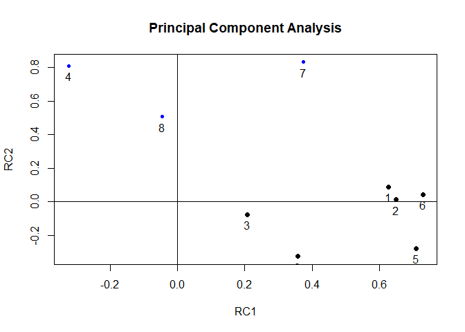

```r
fa.plot(fit.pc)
```

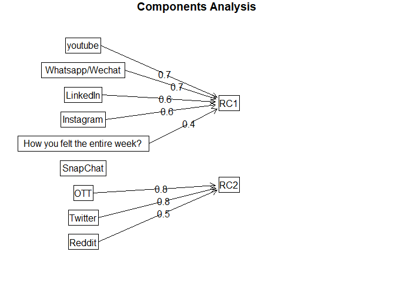

```r
fa.diagram(fit.pc) # Visualize the relationship
```

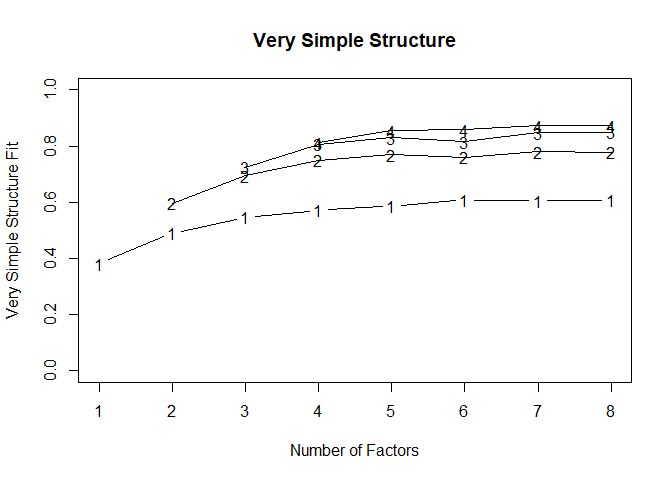

```
##
## Very Simple Structure
## Call: vss(x = social_media_numeric)
## VSS complexity 1 achieves a maximimum of 0.61  with  6  factors
## VSS complexity 2 achieves a maximimum of 0.78  with  7  factors
##
## The Velicer MAP achieves a minimum of 0.06  with  1  factors
## BIC achieves a minimum of  -53.17  with  1  factors
## Sample Size adjusted BIC achieves a minimum of  1.47  with  5  factors
##
## Statistics by number of factors
##   vss1 vss2   map dof   chisq prob sqresid  fit RMSEA   BIC SABIC complex
## 1 0.38 0.00 0.062  27 2.9e+01 0.36     8.1 0.38 0.035 -53.2  30.2     1.0
## 2 0.49 0.60 0.080  19 1.4e+01 0.81     5.3 0.60 0.000 -44.2  14.4     1.2
## 3 0.55 0.69 0.101  12 7.9e+00 0.79     3.6 0.72 0.000 -28.6   8.4     1.3
## 4 0.57 0.75 0.133   6 5.0e+00 0.55     2.5 0.81 0.000 -13.3   5.2     1.6
## 5 0.59 0.77 0.199   1 1.4e+00 0.23     1.9 0.86 0.134  -1.6   1.5     1.6
## 6 0.61 0.76 0.282  -3 4.5e-08   NA     1.5 0.88    NA    NA    NA     1.7
## 7 0.61 0.78 0.439  -6 2.5e-10   NA     1.3 0.90    NA    NA    NA     1.6
## 8 0.61 0.78 1.000  -8 0.0e+00   NA     1.3 0.90    NA    NA    NA     1.6
##    eChisq    SRMR eCRMS  eBIC
## 1 3.9e+01 1.6e-01 0.186 -43.2
## 2 1.6e+01 1.0e-01 0.140 -42.2
## 3 6.1e+00 6.3e-02 0.110 -30.5
## 4 1.9e+00 3.6e-02 0.087 -16.3
## 5 5.7e-01 1.9e-02 0.116  -2.5
## 6 1.2e-08 2.9e-06    NA    NA
## 7 3.0e-11 1.4e-07    NA    NA
## 8 3.2e-16 4.6e-10    NA    NA
```

```r
vss(social_media_numeric)
```

Very Simple Structure Call: vss(x = social_media_numeric) VSS complexity 1 achieves a maximimum of 0.61 with 6 factors VSS complexity 2 achieves a maximimum of 0.78 with 7 factors

The Velicer MAP achieves a minimum of 0.06 with 1 factors BIC achieves a minimum of -53.17 with 1 factors Sample Size adjusted BIC achieves a minimum of 1.47 with 5 factors

Statistics by number of factors

```r
# Computing Correlation Matrix
corrm.social <- cor(social_media_numeric)
corrm.social
```

```
##                                 Instagram     LinkedIn    SnapChat    Twitter
## Instagram                      1.00000000  0.097056399  0.28968877 -0.1930565
## LinkedIn                       0.09705640  1.000000000  0.02552545 -0.1300685
## SnapChat                       0.28968877  0.025525452  1.00000000 -0.1799569
## Twitter                       -0.19305653 -0.130068464 -0.17995686  1.0000000
## Whatsapp/Wechat                0.37769615  0.228835623  0.08099980 -0.4958329
## youtube                        0.33000187  0.452197669 -0.16006877 -0.1881777
## OTT                            0.26738122  0.185492527  0.13158590  0.5570740
## Reddit                        -0.07461553 -0.006992884 -0.08116237  0.1649030
## How you felt the entire week? -0.06488863  0.415506031  0.07962803 -0.1455712
##                               Whatsapp/Wechat     youtube        OTT
## Instagram                           0.3776962  0.33000187  0.2673812
## LinkedIn                            0.2288356  0.45219767  0.1854925
## SnapChat                            0.0809998 -0.16006877  0.1315859
## Twitter                            -0.4958329 -0.18817769  0.5570740
## Whatsapp/Wechat                     1.0000000  0.37168516  0.1336204
## youtube                             0.3716852  1.00000000  0.1605652
## OTT                                 0.1336204  0.16056523  1.0000000
## Reddit                             -0.1344497  0.02639991  0.2327911
## How you felt the entire week?       0.1877267  0.17877463 -0.1088494
##                                     Reddit How you felt the entire week?
## Instagram                     -0.074615529                   -0.06488863
## LinkedIn                      -0.006992884                    0.41550603
## SnapChat                      -0.081162369                    0.07962803
## Twitter                        0.164902964                   -0.14557124
## Whatsapp/Wechat               -0.134449660                    0.18772672
## youtube                        0.026399913                    0.17877463
## OTT                            0.232791099                   -0.10884945
## Reddit                         1.000000000                   -0.15598604
## How you felt the entire week? -0.155986035                    1.00000000
```

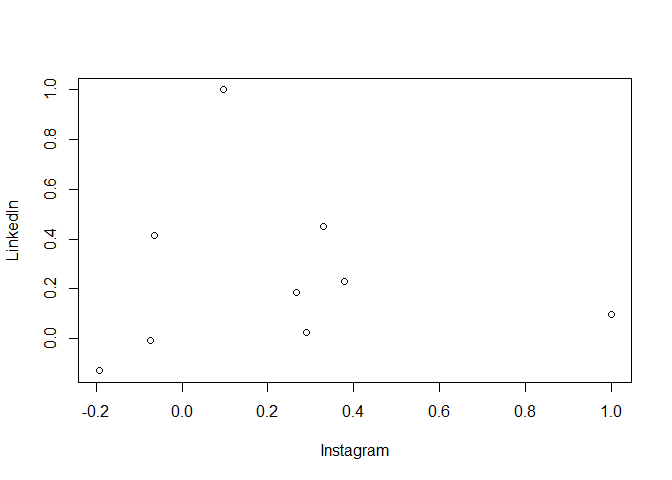

```r
plot(corrm.social)
```

```r
social_pca <- prcomp(social_media_numeric, scale=TRUE)
summary(social_pca)
```

```
## Importance of components:
##                          PC1    PC2    PC3    PC4     PC5     PC6     PC7
## Standard deviation     1.533 1.3119 1.1705 1.0456 0.93113 0.78196 0.70503
## Proportion of Variance 0.261 0.1912 0.1522 0.1215 0.09633 0.06794 0.05523
## Cumulative Proportion  0.261 0.4522 0.6045 0.7259 0.82225 0.89019 0.94542
##                            PC8     PC9
## Standard deviation     0.60784 0.34892
## Proportion of Variance 0.04105 0.01353
## Cumulative Proportion  0.98647 1.00000
```

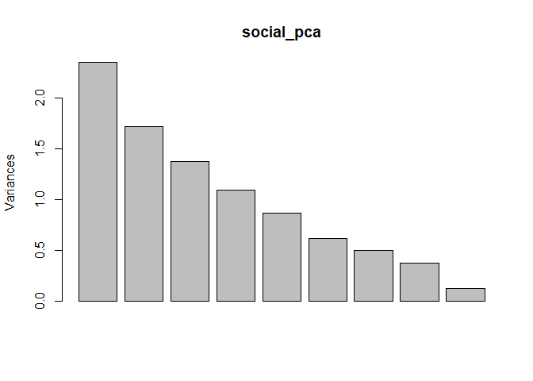

```r
plot(social_pca)
```

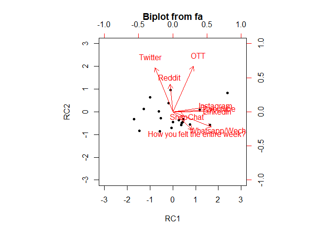

```r
biplot(fit.pc)
```

Overall, these techniques complement each other and can be used together to gain a comprehensive understanding of the data, uncover hidden patterns and structures, and derive meaningful insights for decision-making and further analysis